# Chapter 9 ARIMA

# ARIMA modelling in R

## How does ARIMA() work? (1/7)

**A non-seasonal ARIMA process**

$$\phi(B)(1-B)^d y_{t} = c + \theta(B) \epsilon_t$$

. . .

Need to select appropriate orders: **$p, q, d$**

. . .

**Hyndman and Khandakar (JSS, 2008) algorithm:**

- Select no. differences **$d$** and **$D$** via KPSS test and seasonal strength measure.
- Select **$p, q$** by minimizing AICc.
- Use stepwise search to traverse model space.

## How does ARIMA() work? (2/7)

**AICc Calculation**

$$\text{AICc} = -2 \log(L) + 2(p+q+k+1)\left[1 + \frac{(p+q+k+2)}{T-p-q-k-2}\right].$$

where $L$ is the maximized likelihood fitted to the *differenced* data, $k=1$ if $c \ne 0$ and $k=0$ otherwise.

**Step 1:**

Select current model (with smallest AICc) from:

- ARIMA$(2,d,2)$
- ARIMA$(0,d,0)$
- ARIMA$(1,d,0)$
- ARIMA$(0,d,1)$

## How does ARIMA() work? (3/7)

**Step 2:**

Consider variations of current model: - Vary one of $p, q$ from current model by $\pm1$ - $p, q$ both vary from current model by $\pm1$ - Include/exclude $c$ from current model

Model with lowest AICc becomes current model.

**Repeat Step 2 until no lower AICc can be found.**

## How does ARIMA() work? (4/7)

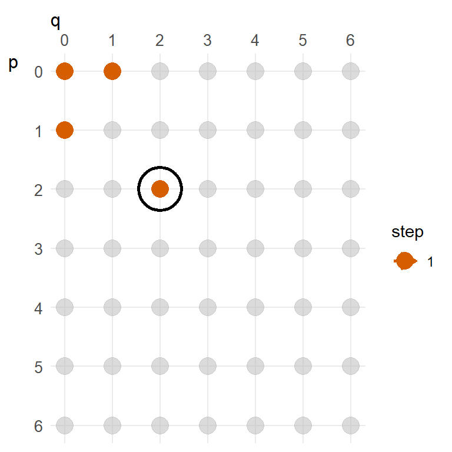

## How does ARIMA() work? (5/7)

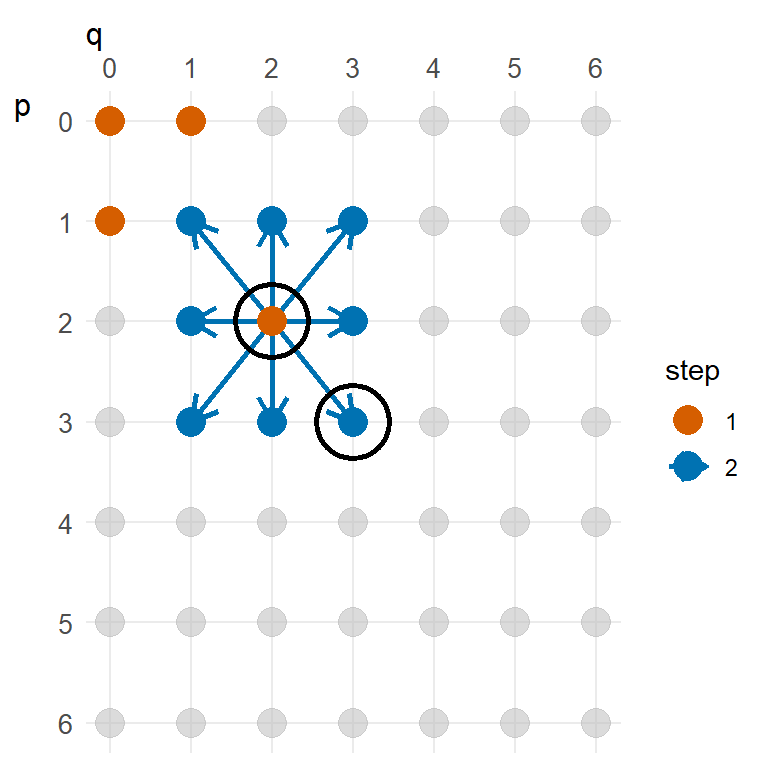

## How does ARIMA() work? (6/7)

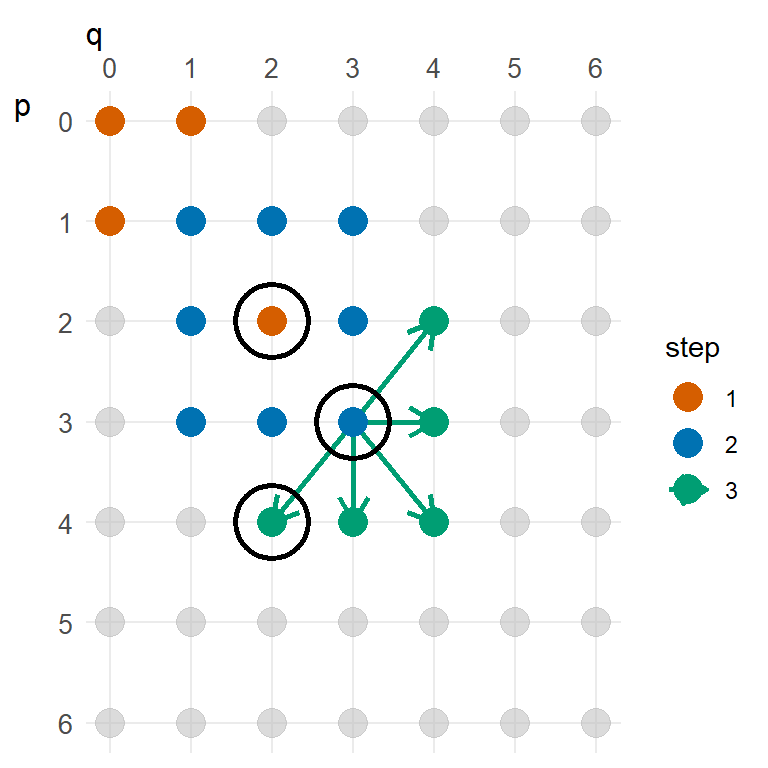

## How does ARIMA() work? (7/7)

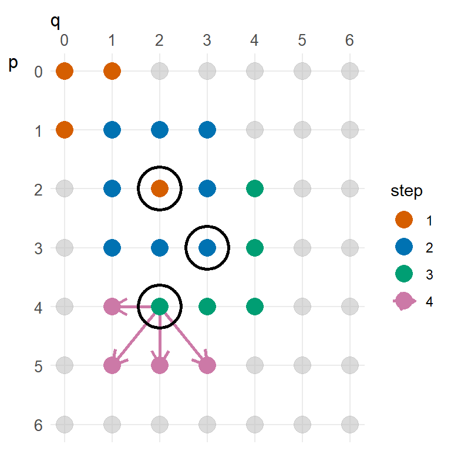

## Egyptian exports

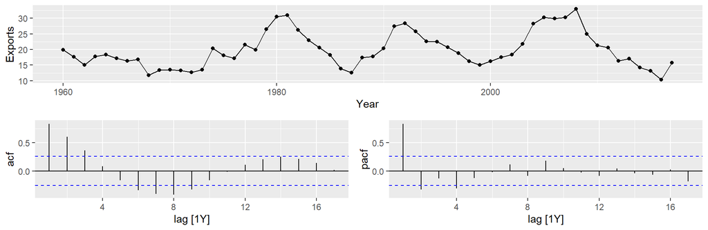

```r
global_economy |> filter(Code == "EGY") |>
  gg_tsdisplay(Exports, plot_type='partial')
```

## Egyptian exports

```r
fit1 <- global_economy |>
  filter(Code == "EGY") |>
  model(ARIMA(Exports ~ pdq(4,0,0)))
report(fit1)
```

```
Series: Exports
Model: ARIMA(4,0,0) w/ mean

Coefficients:
         ar1      ar2     ar3      ar4  constant
      0.9861  -0.1715  0.1807  -0.3283    6.6922
s.e.  0.1247   0.1865  0.1865   0.1273    0.3562

sigma^2 estimated as 7.885:  log likelihood=-140.53
AIC=293.05   AICc=294.7   BIC=305.41
```

## Egyptian exports

```r
fit2 <- global_economy |>
  filter(Code == "EGY") |>
  model(ARIMA(Exports))
report(fit2)
```

```
Series: Exports
Model: ARIMA(2,0,1) w/ mean

Coefficients:
         ar1      ar2      ma1  constant
      1.6764  -0.8034  -0.6896    2.5623
s.e.  0.1111   0.0928   0.1492    0.1161

sigma^2 estimated as 8.046:  log likelihood=-141.57
AIC=293.13   AICc=294.29   BIC=303.43
```

## Central African Republic exports (1/8)

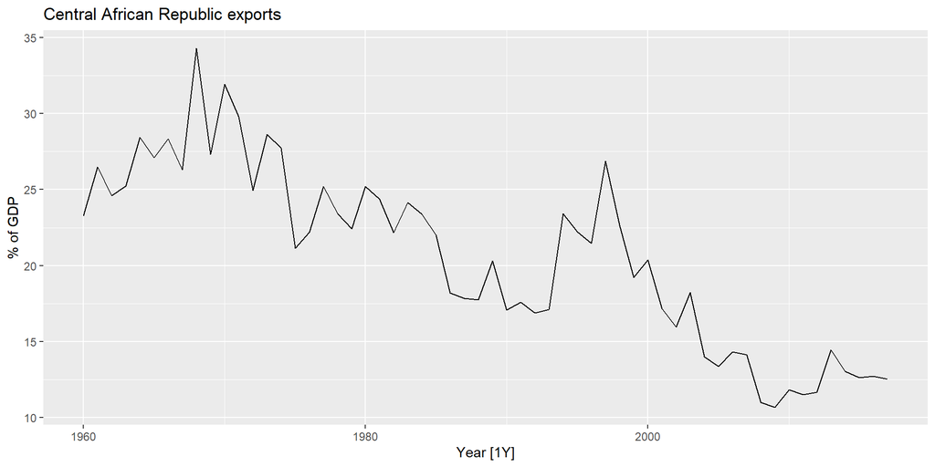

```r
global_economy |>
  filter(Code == "CAF") |>
  autoplot(Exports) +
  labs(title="Central African Republic exports", y="% of GDP")
```

## Central African Republic exports (2/8)

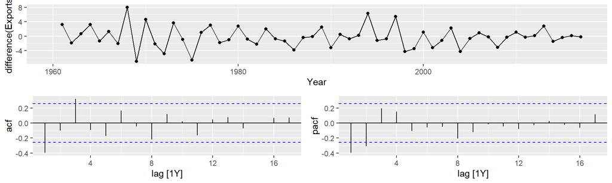

```r
global_economy |>
  filter(Code == "CAF") |>
  gg_tsdisplay(difference(Exports), plot_type='partial')
```

## Central African Republic exports (3/8)

```r
caf_fit <- global_economy |>
  filter(Code == "CAF") |>
  model(arima210 = ARIMA(Exports ~ pdq(2,1,0)),
        arima013 = ARIMA(Exports ~ pdq(0,1,3)),
        stepwise = ARIMA(Exports),
        search = ARIMA(Exports, stepwise=FALSE))
```

## Central African Republic exports (4/8)

```r
caf_fit |> pivot_longer(!Country, names_to = "Model name",
                         values_to = "Orders")
```

```
# A mable: 4 x 3
# Key:     Country, Model name [4]
  Country                  `Model name`         Orders
  <fct>                    <chr>               <model>
1 Central African Republic arima210     <ARIMA(2,1,0)>
2 Central African Republic arima013     <ARIMA(0,1,3)>
3 Central African Republic stepwise     <ARIMA(2,1,2)>
4 Central African Republic search       <ARIMA(3,1,0)>
```

## Central African Republic exports (5/8)

```r
glance(caf_fit) |> arrange(AICc) |> select(.model:BIC)
```

```
# A tibble: 4 × 6
  .model   sigma2 log_lik   AIC  AICc   BIC
  <chr>     <dbl>   <dbl> <dbl> <dbl> <dbl>
1 search     6.52   -133.  274.  275.  282.
2 arima210   6.71   -134.  275.  275.  281.
3 arima013   6.54   -133.  274.  275.  282.
4 stepwise   6.42   -132.  274.  275.  284.
```

## Central African Republic exports (6/8)

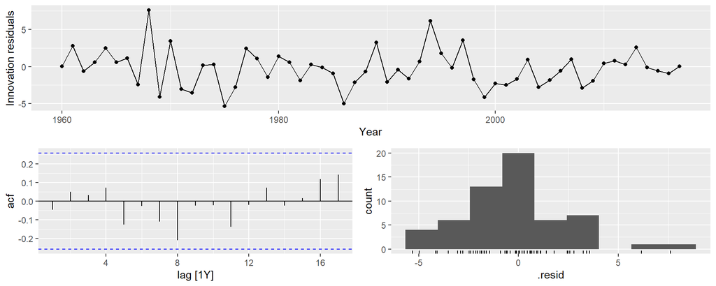

```r
caf_fit |> select(search) |> gg_tsresiduals()
```

## Central African Republic exports (7/8)

```r
augment(caf_fit) |>
  filter(.model=='search') |>
  features(.innov, ljung_box, lag = 10, dof = 3)
```

```
# A tibble: 1 × 4
  Country                  .model lb_stat lb_pvalue
  <fct>                    <chr>    <dbl>     <dbl>
1 Central African Republic search    5.75     0.569
```

## Central African Republic exports (8/8)

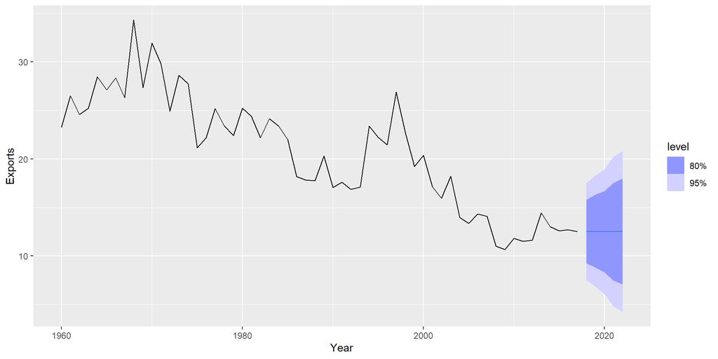

```r
caf_fit |>
  forecast(h=5) |>
  filter(.model=='search') |>
  autoplot(global_economy)
```

## Modelling procedure with `ARIMA()`

1. Plot the data. Identify any unusual observations.
2. If necessary, transform the data (using a Box-Cox transformation) to stabilize the variance.
3. If the data are non-stationary: take first differences of the data until the data are stationary.
4. Examine the ACF/PACF: Is an AR($p$) or MA($q$) model appropriate?
5. Try your chosen model(s), and use the *AICc* to search for a better model.
6. Check the residuals from your chosen model by plotting the ACF of the residuals, and doing a portmanteau test of the residuals. If they do not look like white noise, try a modified model.
7. Once the residuals look like white noise, calculate forecasts.

## Automatic modelling procedure with `ARIMA()`

1. Plot the data. Identify any unusual observations.
2. If necessary, transform the data (using a Box-Cox transformation) to stabilize the variance.

. . .

3. Use `ARIMA` to automatically select a model.

. . .

6. Check the residuals from your chosen model by plotting the ACF of the residuals, and doing a portmanteau test of the residuals. If they do not look like white noise, try a modified model.
7. Once the residuals look like white noise, calculate forecasts.

## Modelling procedure

[interactive chart not shown]

# Forecasting

## Prediction intervals

**95% prediction interval**

$$\hat{y}_{T+h|T} \pm 1.96\sqrt{v_{T+h|T}}$$

where $v_{T+h|T}$ is estimated forecast variance.

## Prediction intervals

Multi-step prediction intervals for ARIMA(0,0,$q$):

$$y_t = \epsilon_t + \sum_{i=1}^q \theta_i \varepsilon_{t-i}.$$

$$v_{T|T+h} = \hat{\sigma}^2 \left[ 1 + \sum_{i=1}^{h-1} \theta_i^2\right], \qquad \text{for } h=2,3,\dots.$$

. . .

- AR(1): Can be rewritten as MA($\infty$) and use above result.
- Other models beyond scope of this subject.

## Prediction intervals

- Prediction intervals **increase in size with forecast horizon**.
- Prediction intervals can be difficult to calculate by hand
- Calculations assume residuals are **uncorrelated** and **normally distributed**.
- Prediction intervals tend to be too narrow.
  - the uncertainty in the parameter estimates has not been accounted for.
  - the ARIMA model assumes historical patterns will not change during the forecast period.
  - the ARIMA model assumes uncorrelated future errors

## Your turn

For the GDP data (from `global_economy`):

- fit a suitable ARIMA model to the logged data for all countries
- check the residual diagnostics for Australia;
- produce forecasts of your fitted model for Australia.

# Backshift notation revisited

## Recall Backshift notation

Backward shift operator, $B$, which is used as follows:
$$B y_{t} = y_{t - 1} \: .$$

. . .

$B$, operating on $y_{t}$, has the effect of **shifting the data back one period**.

. . .

For monthly data, if we wish to shift attention to “the same month last year,” then $B^{12}$ is used, and the notation is $B^{12}y_{t} = y_{t-12}$.

# Seasonal ARIMA models

## Seasonal ARIMA models

| ARIMA | $~\underbrace{(p, d, q)}$ | $\underbrace{(P, D, Q)_{m}}$ |
| --- | --- | --- |
|  | ${\uparrow}$ | ${\uparrow}$ |
|  | Non-seasonal part | Seasonal part of |
|  | of the model | of the model |

where $m =$ number of observations per year.

## ARIMA$(1, 1, 1)(1, 1, 1)_{4}$ model (without constant)

$$\begin{aligned}
&\underbrace{(1 - \phi_1 B)}_{\text{Non-seasonal AR(1)} \phantom{X}}
\underbrace{(1 - \Phi_1 B^4)}_{\text{Seasonal AR(1)} \phantom{X}}
\underbrace{(1 - B)}_{\text{Non-seasonal difference} \phantom{X}}
\underbrace{(1 - B^4)}_{\text{Seasonal difference} \phantom{X}}
y_t = \\
&\underbrace{(1 + \theta_1 B)}_{\text{Non-seasonal MA(1)} \phantom{X}}
\underbrace{(1 + \Theta_1 B^4)}_{\text{Seasonal MA(1)} \phantom{X}}
\varepsilon_t
\end{aligned}$$

## Seasonal ARIMA models

E.g., ARIMA$(1, 1, 1)(1, 1, 1)_{4}$ model (without constant)

$$(1 - \phi_{1}B)(1 - \Phi_{1}B^{4}) (1 - B) (1 - B^{4})y_{t} =(1 + \theta_{1}B) (1 + \Theta_{1}B^{4})\epsilon_{t}.$$

## Common ARIMA models

The US Census Bureau uses the following models most often:

| Model | Transformation |
| --- | --- |
| ARIMA(0,1,1)(0,1,1)$_m$ | with log transformation |
| ARIMA(0,1,2)(0,1,1)$_m$ | with log transformation |
| ARIMA(2,1,0)(0,1,1)$_m$ | with log transformation |
| ARIMA(0,2,2)(0,1,1)$_m$ | with log transformation |
| ARIMA(2,1,2)(0,1,1)$_m$ | with no transformation |

## Seasonal ARIMA models

The seasonal part of an AR or MA model will be seen in the seasonal lags of the PACF and ACF.

**ARIMA(0,0,0)(0,0,1)$_{12}$ will show:**

- a spike at lag 12 in the ACF but no other significant spikes.
- The PACF will show exponential decay in the seasonal lags; that is, at lags 12, 24, 36, .

. . .

**ARIMA(0,0,0)(1,0,0)$_{12}$ will show:**

- exponential decay in the seasonal lags of the ACF
- a single significant spike at lag 12 in the PACF.

## US leisure employment (1/8)

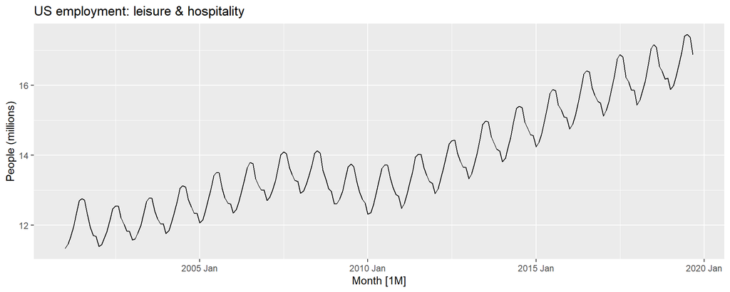

```r
leisure <- us_employment |>
  filter(Title == "Leisure and Hospitality", year(Month) > 2000) |>
  mutate(Employed = Employed/1000) |>
  select(Month, Employed)
autoplot(leisure, Employed) +
  labs(title = "US employment: leisure & hospitality", y="People (millions)")
```

## US leisure employment (2/8)

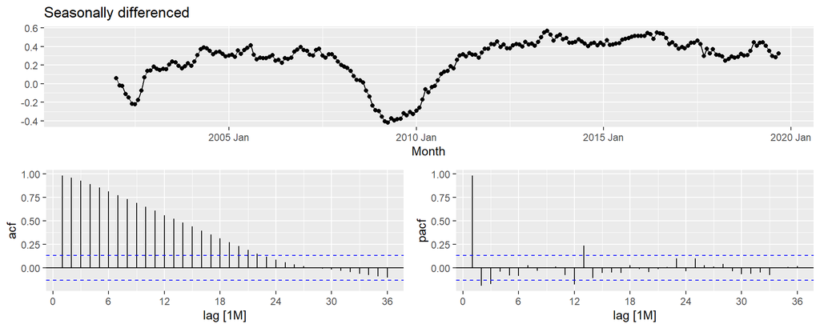

```r
leisure |>
  gg_tsdisplay(difference(Employed, 12), plot_type='partial', lag=36) +
  labs(title="Seasonally differenced", y="")
```

## US leisure employment (3/8)

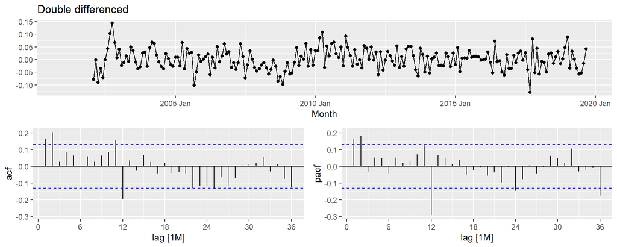

```r
leisure |>
  gg_tsdisplay(difference(Employed, 12) |> difference(),
    plot_type='partial', lag=36) +
  labs(title = "Double differenced", y="")
```

## US leisure employment (4/8)

```r
fit <- leisure |>
  model(
    arima012011 = ARIMA(Employed ~ pdq(0,1,2) + PDQ(0,1,1)),
    arima210011 = ARIMA(Employed ~ pdq(2,1,0) + PDQ(0,1,1)),
    auto = ARIMA(Employed, stepwise = FALSE, approx = FALSE)
  )
fit |> pivot_longer(everything(), names_to = "Model name",
                     values_to = "Orders")
```

```
# A mable: 3 x 2
# Key:     Model name [3]
  `Model name`                    Orders
  <chr>                          <model>
1 arima012011  <ARIMA(0,1,2)(0,1,1)[12]>
2 arima210011  <ARIMA(2,1,0)(0,1,1)[12]>
3 auto         <ARIMA(2,1,0)(1,1,1)[12]>
```

## US leisure employment (5/8)

```r
glance(fit) |> arrange(AICc) |> select(.model:BIC)
```

```
# A tibble: 3 × 6
  .model       sigma2 log_lik   AIC  AICc   BIC
  <chr>         <dbl>   <dbl> <dbl> <dbl> <dbl>
1 auto        0.00142    395. -780. -780. -763.
2 arima210011 0.00145    392. -776. -776. -763.
3 arima012011 0.00146    391. -775. -775. -761.
```

## US leisure employment (6/8)

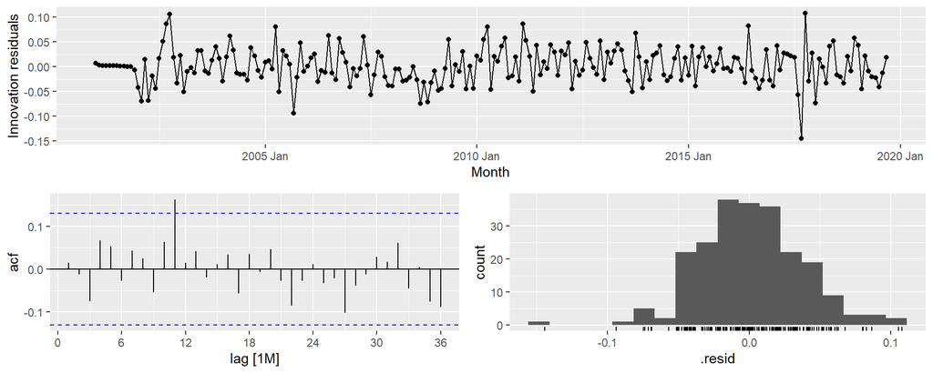

```r
fit |> select(auto) |> gg_tsresiduals(lag=36)
```

## US leisure employment (7/8)

```r
augment(fit) |> features(.innov, ljung_box, lag=24, dof=4)
```

```
# A tibble: 3 × 3
  .model      lb_stat lb_pvalue
  <chr>         <dbl>     <dbl>
1 arima012011    22.4     0.320
2 arima210011    18.9     0.527
3 auto           16.6     0.680
```

## US leisure employment (8/8)

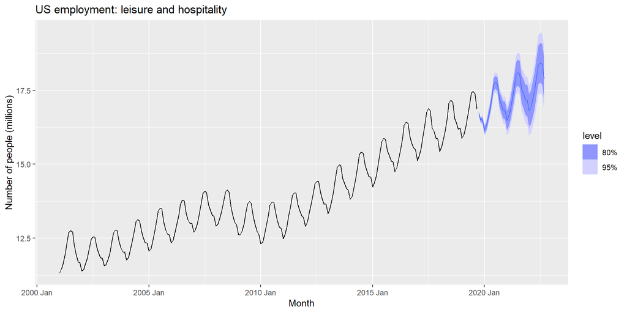

```r
forecast(fit, h=36) |>
  filter(.model=='auto') |>
  autoplot(leisure) +
  labs(title = "US employment: leisure and hospitality", y="Number of people (millions)")
```

## Cortecosteroid drug sales (1/20)

```r
h02 <- PBS |>
  filter(ATC2 == "H02") |>
  summarise(Cost = sum(Cost)/1e6)
```

## Cortecosteroid drug sales (2/20)

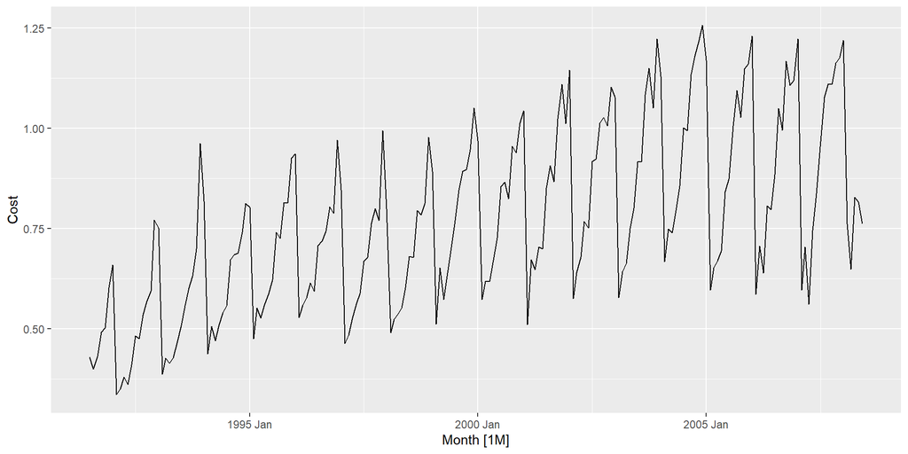

```r
h02 |> autoplot(
  Cost
)
```

## Cortecosteroid drug sales (3/20)

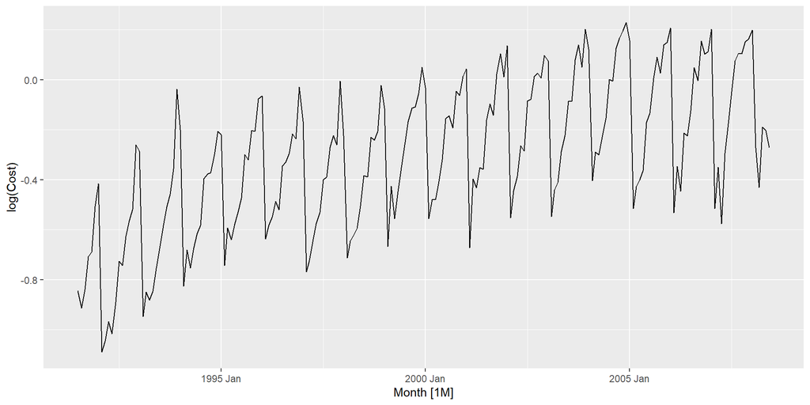

```r
h02 |> autoplot(
  log(Cost)
)
```

## Cortecosteroid drug sales (4/20)

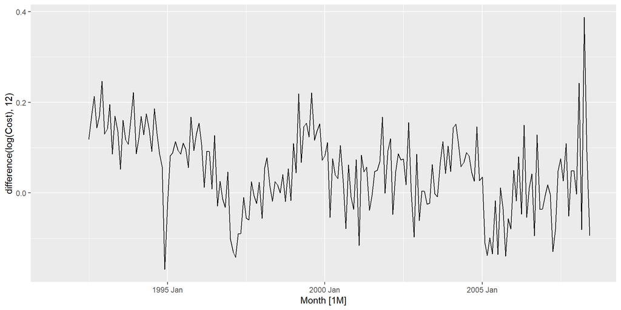

```r
h02 |> autoplot(
  log(Cost) |> difference(12)
)
```

## Cortecosteroid drug sales (5/20)

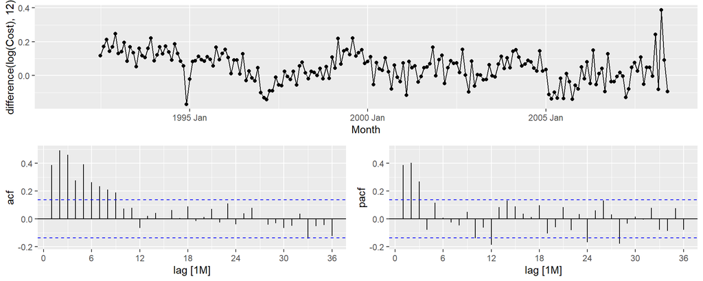

```r
h02 |> gg_tsdisplay(difference(log(Cost),12),
                 lag_max = 36, plot_type = 'partial')
```

## Cortecosteroid drug sales (6/20)

- Choose $D=1$ and $d=0$.
- Spikes in PACF at lags 12 and 24 suggest seasonal AR(2) term.
- Spikes in PACF suggests possible non-seasonal AR(3) term.
- Initial candidate model: ARIMA(3,0,0)(2,1,0)$_{12}$.

## Cortecosteroid drug sales (7/20)

| .model | AICc |
| --- | --- |
| ARIMA(3,0,1)(0,1,2)[12] | -485.48 |
| ARIMA(3,0,1)(1,1,1)[12] | -484.25 |
| ARIMA(3,0,1)(0,1,1)[12] | -483.67 |
| ARIMA(3,0,1)(2,1,0)[12] | -476.31 |
| ARIMA(3,0,0)(2,1,0)[12] | -475.12 |
| ARIMA(3,0,2)(2,1,0)[12] | -474.88 |
| ARIMA(3,0,1)(1,1,0)[12] | -463.40 |

## Cortecosteroid drug sales (8/20)

```r
fit <- h02 |>
  model(best = ARIMA(log(Cost) ~ 0 + pdq(3,0,1) + PDQ(0,1,2)))
report(fit)
```

```
Series: Cost
Model: ARIMA(3,0,1)(0,1,2)[12]
Transformation: log(Cost)

Coefficients:
          ar1     ar2     ar3     ma1     sma1     sma2
      -0.1603  0.5481  0.5678  0.3827  -0.5222  -0.1768
s.e.   0.1636  0.0878  0.0942  0.1895   0.0861   0.0872

sigma^2 estimated as 0.004278:  log likelihood=250.04
AIC=-486.08   AICc=-485.48   BIC=-463.28
```

## Cortecosteroid drug sales (9/20)

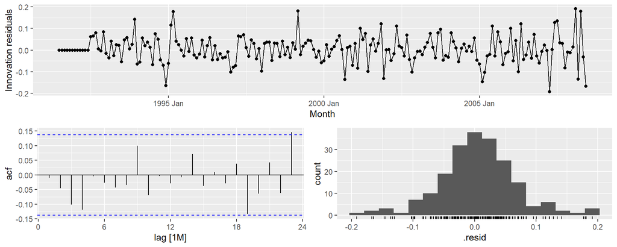

```r
gg_tsresiduals(fit)
```

## Cortecosteroid drug sales (10/20)

```r
augment(fit) |>
  features(.innov, ljung_box, lag = 36, dof = 6)
```

```
# A tibble: 1 × 3
  .model lb_stat lb_pvalue
  <chr>    <dbl>     <dbl>
1 best      50.7    0.0104
```

## Cortecosteroid drug sales (11/20)

```r
fit <- h02 |> model(auto = ARIMA(log(Cost)))
report(fit)
```

```
Series: Cost
Model: ARIMA(2,1,0)(0,1,1)[12]
Transformation: log(Cost)

Coefficients:
          ar1      ar2     sma1
      -0.8491  -0.4207  -0.6401
s.e.   0.0712   0.0714   0.0694

sigma^2 estimated as 0.004387:  log likelihood=245.39
AIC=-482.78   AICc=-482.56   BIC=-469.77
```

## Cortecosteroid drug sales (12/20)

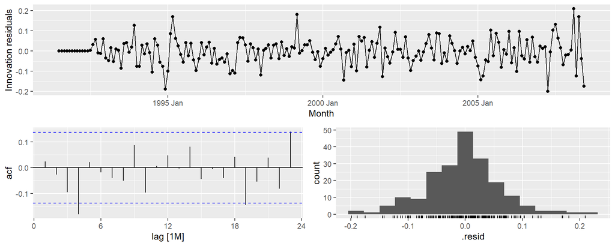

```r
gg_tsresiduals(fit)
```

## Cortecosteroid drug sales (13/20)

```r
augment(fit) |>
  features(.innov, ljung_box, lag = 36, dof = 3)
```

```
# A tibble: 1 × 3
  .model lb_stat lb_pvalue
  <chr>    <dbl>     <dbl>
1 auto      59.3   0.00332
```

## Cortecosteroid drug sales (14/20)

```r
fit <- h02 |>
  model(best = ARIMA(log(Cost), stepwise = FALSE,
                 approximation = FALSE,
                 order_constraint = p + q + P + Q <= 9))
report(fit)
```

```
Series: Cost
Model: ARIMA(4,1,1)(2,1,2)[12]
Transformation: log(Cost)

Coefficients:
          ar1     ar2     ar3      ar4      ma1    sar1     sar2     sma1    sma2
      -0.0425  0.2098  0.2017  -0.2273  -0.7424  0.6213  -0.3832  -1.2019  0.4959
s.e.   0.2167  0.1813  0.1144   0.0810   0.2074  0.2421   0.1185   0.2491  0.2135

sigma^2 estimated as 0.004049:  log likelihood=254.31
AIC=-488.63   AICc=-487.4   BIC=-456.1
```

## Cortecosteroid drug sales (15/20)

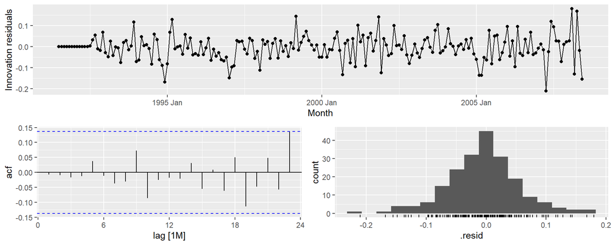

```r
gg_tsresiduals(fit)
```

## Cortecosteroid drug sales (16/20)

```r
augment(fit) |>
  features(.innov, ljung_box, lag = 36, dof = 9)
```

```
# A tibble: 1 × 3
  .model lb_stat lb_pvalue
  <chr>    <dbl>     <dbl>
1 best      36.5     0.106
```

## Cortecosteroid drug sales (17/20)

Training data: July 1991 to June 2006

Test data: July 2006–June 2008

```r
fit <- h02 |>
  filter_index(~ "2006 Jun") |>
  model(
    ARIMA(log(Cost) ~ 0 + pdq(3, 0, 0) + PDQ(2, 1, 0)),
    ARIMA(log(Cost) ~ 0 + pdq(3, 0, 1) + PDQ(2, 1, 0)),
    ARIMA(log(Cost) ~ 0 + pdq(3, 0, 2) + PDQ(2, 1, 0)),
    ARIMA(log(Cost) ~ 0 + pdq(3, 0, 1) + PDQ(1, 1, 0))
    # ... #
  )

fit |>
  forecast(h = "2 years") |>
  accuracy(h02)
```

## Cortecosteroid drug sales (18/20)

| .model | RMSE |
| --- | --- |
| ARIMA(3,0,1)(1,1,1)[12] | 0.0619 |
| ARIMA(3,0,1)(0,1,2)[12] | 0.0621 |
| ARIMA(3,0,1)(0,1,1)[12] | 0.0630 |
| ARIMA(2,1,0)(0,1,1)[12] | 0.0630 |
| ARIMA(4,1,1)(2,1,2)[12] | 0.0631 |
| ARIMA(3,0,2)(2,1,0)[12] | 0.0651 |
| ARIMA(3,0,1)(2,1,0)[12] | 0.0653 |
| ARIMA(3,0,1)(1,1,0)[12] | 0.0666 |
| ARIMA(3,0,0)(2,1,0)[12] | 0.0668 |

## Cortecosteroid drug sales (19/20)

- Models with lowest AICc values tend to give slightly better results than the other models.
- AICc comparisons must have the same orders of differencing. But RMSE test set comparisons can involve any models.
- Use the best model available, even if it does not pass all tests.

## Cortecosteroid drug sales (20/20)

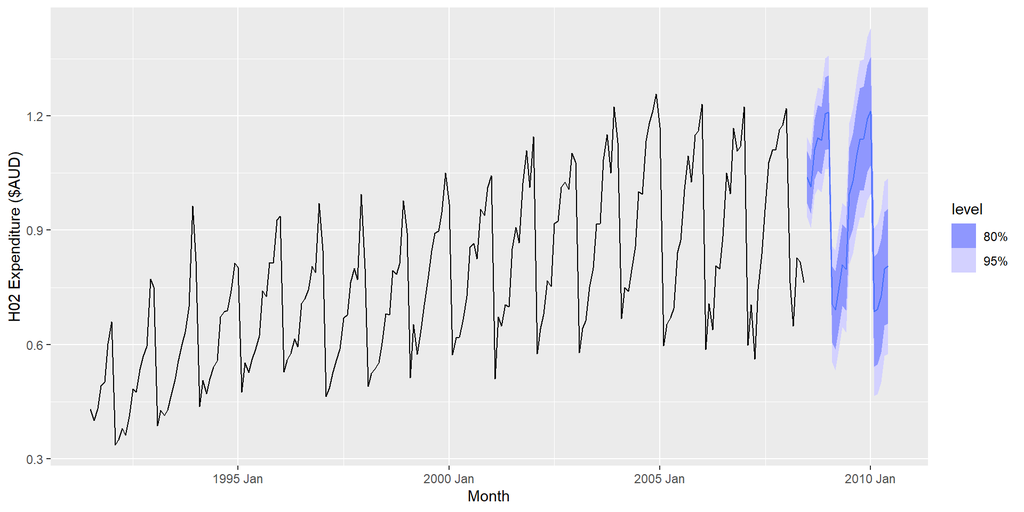

```r
fit <- h02 |>
  model(ARIMA(Cost ~ 0 + pdq(3,0,1) + PDQ(0,1,2)))
fit |> forecast() |> autoplot(h02) +
  labs(y = "H02 Expenditure ($AUD)")
```

# ARIMA vs ETS

## ARIMA vs ETS

- Myth that ARIMA models are more general than exponential smoothing.
- Linear exponential smoothing models all special cases of ARIMA models.
- Non-linear exponential smoothing models have no equivalent ARIMA counterparts.
- Many ARIMA models have no exponential smoothing counterparts.
- ETS models all non-stationary. Models with seasonality or non-damped trend (or both) have two unit roots; all other models have one unit **root.**

## ARIMA vs ETS

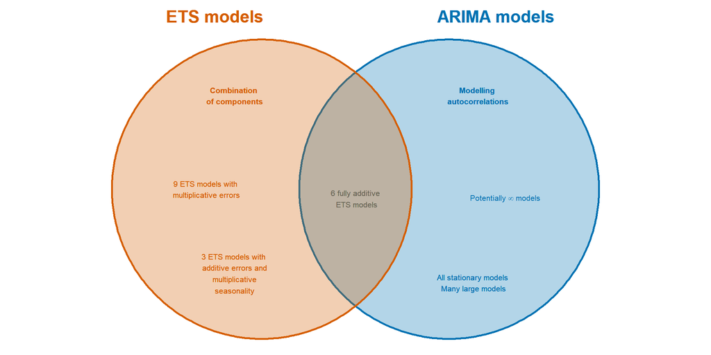

## Equivalences

[output not shown]

## Example: Australian population

```r
aus_economy <- global_economy |> filter(Code == "AUS") |>
  mutate(Population = Population/1e6)
aus_economy |>
  slice(-n()) |>
  stretch_tsibble(.init = 10) |>
  model(ets = ETS(Population),
        arima = ARIMA(Population)
  ) |>
  forecast(h = 1) |>
  accuracy(aus_economy) |>
  select(.model, ME:RMSSE)
```

```
# A tibble: 2 × 8
  .model     ME   RMSE    MAE   MPE  MAPE  MASE RMSSE
  <chr>   <dbl>  <dbl>  <dbl> <dbl> <dbl> <dbl> <dbl>
1 arima  0.0420 0.194  0.0789 0.277 0.509 0.317 0.746
2 ets    0.0202 0.0774 0.0543 0.112 0.327 0.218 0.298
```

## Example: Australian population

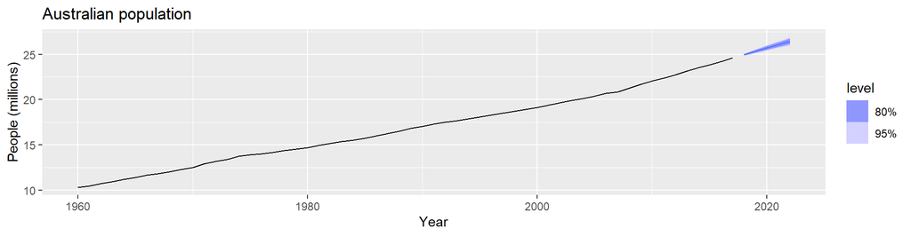

```r
aus_economy |>
  model(ETS(Population)) |>
  forecast(h = "5 years") |>
  autoplot(aus_economy) +
  labs(title = "Australian population",  y = "People (millions)")
```

## Example: Cement production (1/9)

```r
cement <- aus_production |>
  select(Cement) |>
  filter_index("1988 Q1" ~ .)
train <- cement |> filter_index(. ~ "2007 Q4")
fit <- train |>
  model(
    arima = ARIMA(Cement),
    ets = ETS(Cement)
  )
```

## Example: Cement production (2/9)

```r
fit |>
  select(arima) |>
  report()
```

```
Series: Cement
Model: ARIMA(1,0,1)(2,1,1)[4] w/ drift

Coefficients:
         ar1      ma1   sar1     sar2     sma1  constant
      0.8886  -0.2366  0.081  -0.2345  -0.8979    5.3884
s.e.  0.0842   0.1334  0.157   0.1392   0.1780    1.4844

sigma^2 estimated as 11456:  log likelihood=-463.52
AIC=941.03   AICc=942.68   BIC=957.35
```

## Example: Cement production (3/9)

```r
fit |> select(ets) |> report()
```

```
Series: Cement
Model: ETS(M,N,M)
  Smoothing parameters:
    alpha = 0.7533714
    gamma = 0.0001000093

  Initial states:
     l[0]     s[0]    s[-1]    s[-2]     s[-3]
 1694.712 1.031179 1.045209 1.011424 0.9121874

  sigma^2:  0.0034

     AIC     AICc      BIC
1104.095 1105.650 1120.769
```

## Example: Cement production (4/9)

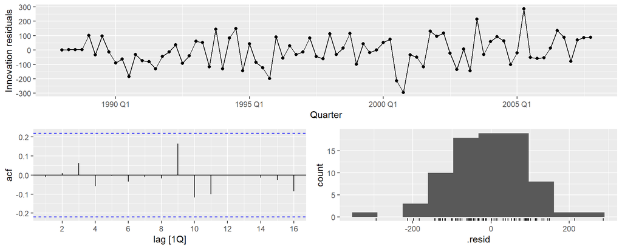

```r
gg_tsresiduals(fit |> select(arima), lag_max = 16)
```

## Example: Cement production (5/9)

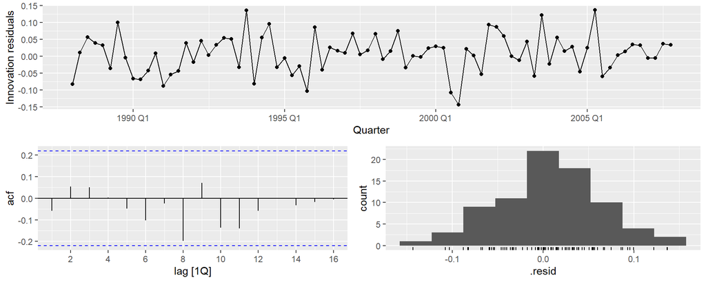

```r
gg_tsresiduals(fit |> select(ets), lag_max = 16)
```

## Example: Cement production (6/9)

```r
fit |>
  select(arima) |>
  augment() |>
  features(.innov, ljung_box, lag = 16, dof = 6)
```

```
# A tibble: 1 × 3
  .model lb_stat lb_pvalue
  <chr>    <dbl>     <dbl>
1 arima     6.37     0.783
```

## Example: Cement production (7/9)

```r
fit |>
  select(ets) |>
  augment() |>
  features(.innov, ljung_box, lag = 16, dof = 6)
```

```
# A tibble: 1 × 3
  .model lb_stat lb_pvalue
  <chr>    <dbl>     <dbl>
1 ets       10.0     0.438
```

## Example: Cement production (8/9)

```r
fit |>
  forecast(h = "2 years 6 months") |>
  accuracy(cement) |>
  select(-ME, -MPE, -ACF1)
```

```
# A tibble: 2 × 7
  .model .type  RMSE   MAE  MAPE  MASE RMSSE
  <chr>  <chr> <dbl> <dbl> <dbl> <dbl> <dbl>
1 arima  Test   216.  186.  8.68  1.27  1.26
2 ets    Test   222.  191.  8.85  1.30  1.29
```

## Example: Cement production (9/9)

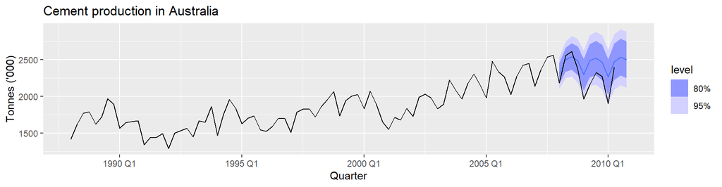

```r
fit |>
  select(arima) |>
  forecast(h="3 years") |>
  autoplot(cement) +
  labs(title = "Cement production in Australia", y="Tonnes ('000)")
```